# Data Preprocessing in R

Jah Chaisangmongkon

July 29, 2017

The caret package in R provides a number of useful data transforms. The `preProcess()` function is used to build the model for data tranformation procedure. Then the model can be applied to dataset using function `predict()`.

Below is a quick summary of all of the transform methods supported in the method argument of the preProcess() function in caret.

- center: subtract mean from values.
- scale: divide values by standard deviation.
- range: normalize values.
- BoxCox: apply a Box–Cox transform, values must be non-zero and positive.
- zv: remove attributes with a zero variance (all the same value).
- nzv: remove attributes with a near zero variance (close to the same value).
- pca: transform data to the principal components.

We will cover only the first four methods in this demo. You can feel free to try the rest yourself.

## Preprocessing iris dataset

```r
library(caret)
data(iris)
summary(iris[,1:4])
```

```
##   Sepal.Length    Sepal.Width     Petal.Length    Petal.Width
##  Min.   :4.300   Min.   :2.000   Min.   :1.000   Min.   :0.100
##  1st Qu.:5.100   1st Qu.:2.800   1st Qu.:1.600   1st Qu.:0.300
##  Median :5.800   Median :3.000   Median :4.350   Median :1.300
##  Mean   :5.843   Mean   :3.057   Mean   :3.758   Mean   :1.199
##  3rd Qu.:6.400   3rd Qu.:3.300   3rd Qu.:5.100   3rd Qu.:1.800
##  Max.   :7.900   Max.   :4.400   Max.   :6.900   Max.   :2.500
```

### Scaling, Centering, Standardize

The scale transform calculates the standard deviation for an attribute and divides each value by that standard deviation.

Preprocessing function will skip over non-numeric data without error, but iris dataset has only numeric variables, so we ignored nothing.

```r
preprocessParams <- preProcess(iris[,1:4], method=c("scale"))
print(preprocessParams)
```

```
## Created from 150 samples and 4 variables
##
## Pre-processing:
##   - ignored (0)
##   - scaled (4)
```

```r
transformed <- predict(preprocessParams, iris[,1:4])
summary(transformed)
```

```
##   Sepal.Length    Sepal.Width      Petal.Length     Petal.Width
##  Min.   :5.193   Min.   : 4.589   Min.   :0.5665   Min.   :0.1312
##  1st Qu.:6.159   1st Qu.: 6.424   1st Qu.:0.9064   1st Qu.:0.3936
##  Median :7.004   Median : 6.883   Median :2.4642   Median :1.7055
##  Mean   :7.057   Mean   : 7.014   Mean   :2.1288   Mean   :1.5734
##  3rd Qu.:7.729   3rd Qu.: 7.571   3rd Qu.:2.8890   3rd Qu.:2.3615
##  Max.   :9.540   Max.   :10.095   Max.   :3.9087   Max.   :3.2798
```

The center transform calculates the mean for an attribute and subtracts it from each value.

```r
preprocessParams <- preProcess(iris[,1:4], method=c("center"))
print(preprocessParams)
```

```
## Created from 150 samples and 4 variables
##
## Pre-processing:
##   - centered (4)
##   - ignored (0)
```

```r
transformed <- predict(preprocessParams, iris[,1:4])
summary(transformed)
```

```
##   Sepal.Length       Sepal.Width        Petal.Length     Petal.Width
##  Min.   :-1.54333   Min.   :-1.05733   Min.   :-2.758   Min.   :-1.0993
##  1st Qu.:-0.74333   1st Qu.:-0.25733   1st Qu.:-2.158   1st Qu.:-0.8993
##  Median :-0.04333   Median :-0.05733   Median : 0.592   Median : 0.1007
##  Mean   : 0.00000   Mean   : 0.00000   Mean   : 0.000   Mean   : 0.0000
##  3rd Qu.: 0.55667   3rd Qu.: 0.24267   3rd Qu.: 1.342   3rd Qu.: 0.6007
##  Max.   : 2.05667   Max.   : 1.34267   Max.   : 3.142   Max.   : 1.3007
```

Combining the scale and center transforms will standardize your data. Attributes will have a mean value of 0 and a standard deviation of 1.

```r
preprocessParams <- preProcess(iris[,1:4], method=c("center", "scale"))
print(preprocessParams)
```

```
## Created from 150 samples and 4 variables
##
## Pre-processing:
##   - centered (4)
##   - ignored (0)
##   - scaled (4)
```

```r
transformed <- predict(preprocessParams, iris[,1:4])
summary(transformed)
```

```
##   Sepal.Length       Sepal.Width       Petal.Length      Petal.Width
##  Min.   :-1.86378   Min.   :-2.4258   Min.   :-1.5623   Min.   :-1.4422
##  1st Qu.:-0.89767   1st Qu.:-0.5904   1st Qu.:-1.2225   1st Qu.:-1.1799
##  Median :-0.05233   Median :-0.1315   Median : 0.3354   Median : 0.1321
##  Mean   : 0.00000   Mean   : 0.0000   Mean   : 0.0000   Mean   : 0.0000
##  3rd Qu.: 0.67225   3rd Qu.: 0.5567   3rd Qu.: 0.7602   3rd Qu.: 0.7880
##  Max.   : 2.48370   Max.   : 3.0805   Max.   : 1.7799   Max.   : 1.7064
```

Data values can be scaled into the range of [0, 1] which is called normalization.

```r
preprocessParams <- preProcess(iris[,1:4], method=c("range"))
print(preprocessParams)
```

```
## Created from 150 samples and 4 variables
##
## Pre-processing:
##   - ignored (0)
##   - re-scaling to [0, 1] (4)
```

```r
transformed <- predict(preprocessParams, iris[,1:4])
summary(transformed)
```

```
##   Sepal.Length     Sepal.Width      Petal.Length     Petal.Width
##  Min.   :0.0000   Min.   :0.0000   Min.   :0.0000   Min.   :0.00000
##  1st Qu.:0.2222   1st Qu.:0.3333   1st Qu.:0.1017   1st Qu.:0.08333
##  Median :0.4167   Median :0.4167   Median :0.5678   Median :0.50000
##  Mean   :0.4287   Mean   :0.4406   Mean   :0.4675   Mean   :0.45806
##  3rd Qu.:0.5833   3rd Qu.:0.5417   3rd Qu.:0.6949   3rd Qu.:0.70833
##  Max.   :1.0000   Max.   :1.0000   Max.   :1.0000   Max.   :1.00000
```

### BoxCox Transformation

When an attribute has a Gaussian-like distribution but is shifted, this is called a skew. The distribution of an attribute can be shifted to reduce the skew and make it more Gaussian. The BoxCox transform can perform this operation (assumes all values are positive).

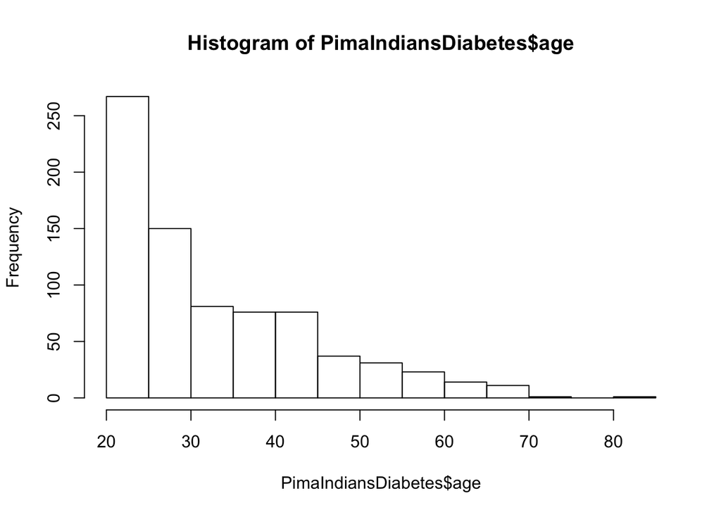

```r
library(mlbench)
data(PimaIndiansDiabetes)
hist(PimaIndiansDiabetes$age)
```

```r
preprocessParams <- preProcess(PimaIndiansDiabetes[c("age","pedigree")], method=c("BoxCox"))
print(preprocessParams)
```

```
## Created from 768 samples and 2 variables
##
## Pre-processing:
##   - Box-Cox transformation (2)
##   - ignored (0)
##
## Lambda estimates for Box-Cox transformation:
## -1.1, -0.1
```

```r
transformed <- predict(preprocessParams, PimaIndiansDiabetes[c("age","pedigree")])
summary(transformed)
```

```
##       age            pedigree
##  Min.   :0.8772   Min.   :-2.5510
##  1st Qu.:0.8815   1st Qu.:-1.4116
##  Median :0.8867   Median :-0.9875
##  Mean   :0.8874   Mean   :-0.9599
##  3rd Qu.:0.8938   3rd Qu.:-0.4680
##  Max.   :0.9019   Max.   : 0.8838
```

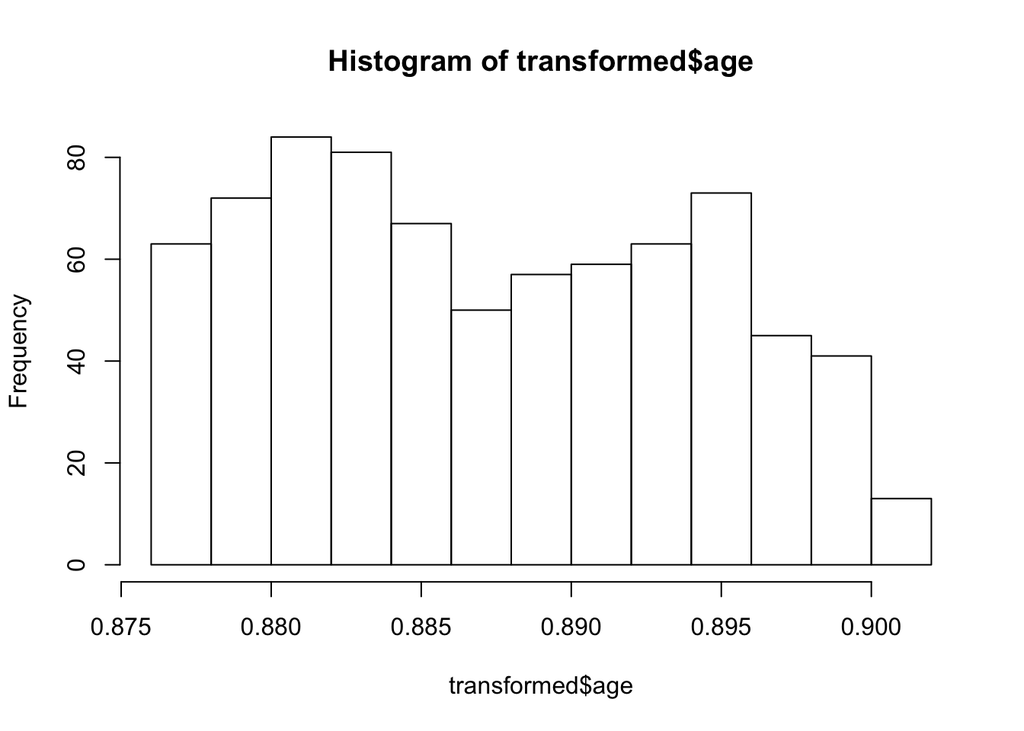

```r
hist(transformed$age)
```

### Dealing with missing data

```r
data("airquality")
df <- airquality
df[4:10,3] <- rep(NA,7)
df[1:5,4] <- NA
df <- df[-c(5,6)]
summary(df)
```

```
##      Ozone           Solar.R           Wind             Temp
##  Min.   :  1.00   Min.   :  7.0   Min.   : 1.700   Min.   :57.00
##  1st Qu.: 18.00   1st Qu.:115.8   1st Qu.: 7.400   1st Qu.:73.00
##  Median : 31.50   Median :205.0   Median : 9.700   Median :79.00
##  Mean   : 42.13   Mean   :185.9   Mean   : 9.806   Mean   :78.28
##  3rd Qu.: 63.25   3rd Qu.:258.8   3rd Qu.:11.500   3rd Qu.:85.00
##  Max.   :168.00   Max.   :334.0   Max.   :20.700   Max.   :97.00
##  NA's   :37       NA's   :7       NA's   :7        NA's   :5
```

### Analyzing missing value ratios

For each row and column, we would like to know how much data is missing. We should consider dropping features with more than 5% missing values (unless you have lots of samples compared to features). Also rows that miss a lot of values should be dropped as well.

```r
library(mice)
md.pattern(df)
```

```
##     Temp Solar.R Wind Ozone
## 104    1       1    1     1  0
##  34    1       1    1     0  1
##   4    1       0    1     1  1
##   3    1       1    0     1  1
##   3    0       1    1     1  1
##   1    1       0    1     0  2
##   1    1       1    0     0  2
##   1    1       0    0     1  2
##   1    0       1    0     1  2
##   1    0       0    0     0  4
##        5       7    7    37 56
```

[output not shown]

```r
completedData <- complete(tempData)
head(completedData)
```

```
##      Ozone  Solar.R      Wind     Temp
## 1 41.00000 190.0000  7.400000 78.27703
## 2 36.00000 118.0000  8.000000 78.27703
## 3 12.00000 149.0000 12.600000 78.27703
## 4 18.00000 313.0000  9.806164 78.27703
## 5 42.12931 185.9315  9.806164 78.27703
## 6 28.00000 185.9315  9.806164 66.00000
```

More learning sources: https://www.r-bloggers.com/imputing-missing-data-with-r-mice-package/